# MA5810 Introduction to Data Mining Assignment 1

# By Sean O’Rourke (13984624)

## Due : 25 July 21

| ## Setup. |
| --- |
| For each question of this assignment the first step is to clear the r work space, import the data and structure the resulting data frame so as it can be easily referenced throughout the investigation.… |

## Question 1

The first step when undertaking any data analysis task is to perform some basic data exploration. The full exploration can be seen in Appendix 1. The following points have been confirmed in this initial exploration:

- all 1200 observations have successfully imported.
- The data types in the data frame appear to be correct with the categorical variable “Ethno” being a factor and the two continuous variables being numeric.
- There are no incomplete observations.
- All 3 categories of the Ethno variable are well, and approximately evenly, represented and the continuous variables are all positive but have very different ranges.

Now that we have a basic understanding of the data we can drill deeper into the data and investigate which classification method would be best suited to predict Ethno using HbA1c and SBP as predictors. Naive Bayes (NB), Linear Discriminant (LDA) and Quadratic Discriminant classifiers (QDA) all use Bayes theorem to apply a probability an observation belongs to each class given the values of the predictor variables. The observation is assigned the class with the highest probability. QDA is a general form of LDA which is a general from of NB. If one were to consider the model graphically, the primary difference between the models is the way in which they deal with the decision boundary, with QDA being the most flexible and NB the least. This characteristic is a function of the assumptions around normality and covariance covariance (and therefore correlation) between the predictor variables. Generally, to avoid over fitting it is good practice to select the least flexible yet suitable model. However if this means the model assumptions are violated it may not be the best choice. Figure 1 shows a scatter plot of the numerical predictors with the points coloured by the categorical response variable. This figure was inspected to inform the following:

- Any noticeable visual groupings between the predictors and Ethno,
- Hints about a suitable decision boundary,
- Distribution of predictor variables,
- Correlation between predictor variables,
- Suitability of assuming a single covariance matrix.

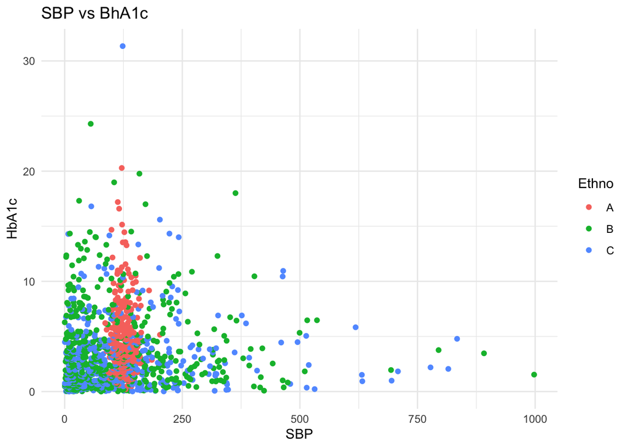

Figure 1: Scatter plot of SBP vs HbA1c coloured by Ethno

It can be seen that the predictor variables do not really distinguish well between all three values of Ethno as there is no clear correlation between HbA1c or SBP and Ethno. Interestignly belonging to class A or not seems to be well correlated with SBP. On first inspection a flexible decision boundary may seem like a good choice in this situation it can ultimately lead to a model which simply follows the noise in the training data rather than capture correlation that may actually exist. We will further explore the attributives of the predictor variables to asses which model is most likely to be suitable.

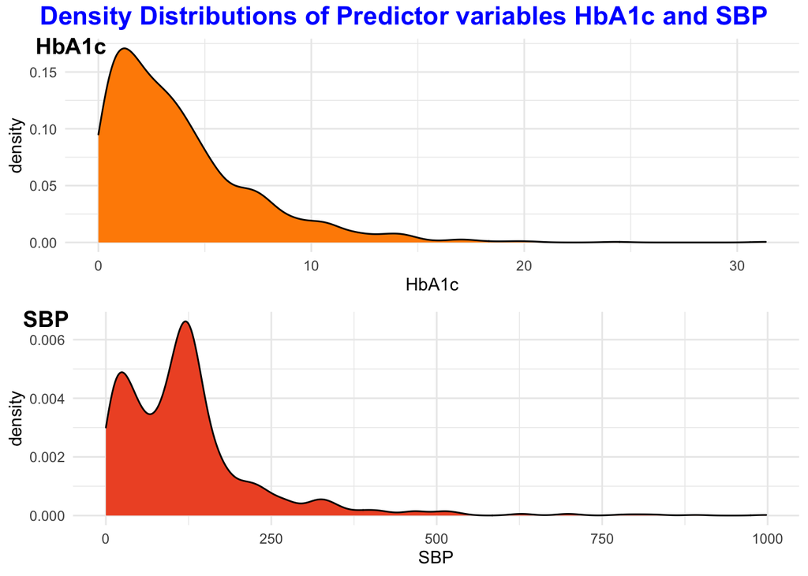

Figure 2: Density Distributions of numeric predictors

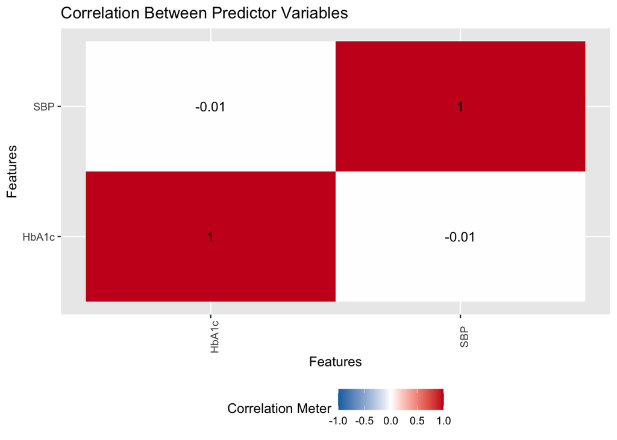

Figure 3: Correlation between predictors

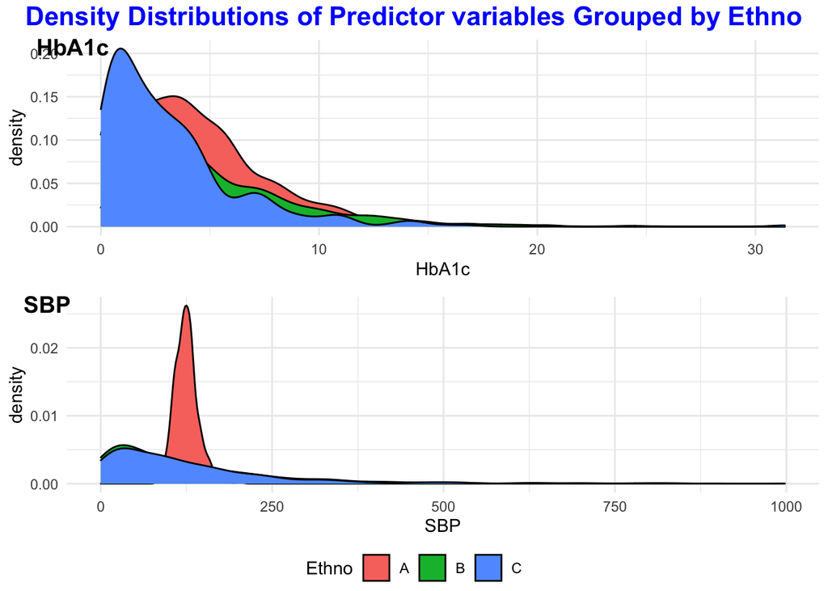

Figure 4: Density Distributions by class and predictor

## Question 2

After importing the data set some basic exploratory visualization and summation was undertaken as can be seen in Apendix 1. From the initial exploration we can note a few critical points about the dataset

- All predictor variables are categorical, this suggests that a Discreate Naive Bayes model will most likely perform best at predicting if a mushroom is edible
- All observations appear to be complete, although stalk root seems to be missing some information as there is a category denoted by “?”
- Veil-Type has only one category and as such will be of little interest to the classifier, this predictor will be dropped
- Many of the classes of the predictor variables have a majority of records in a few levels and the other levels are sparsely populated. When splitting the test and training set and then further splitting for k-folds validation this can be problematic as the sub samples may not contain records with these classes.

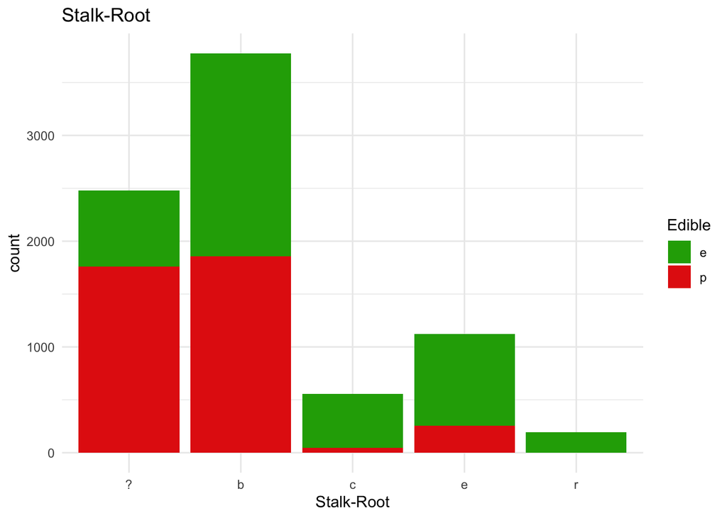

Figure 5: Make up of predictor Stalk Root

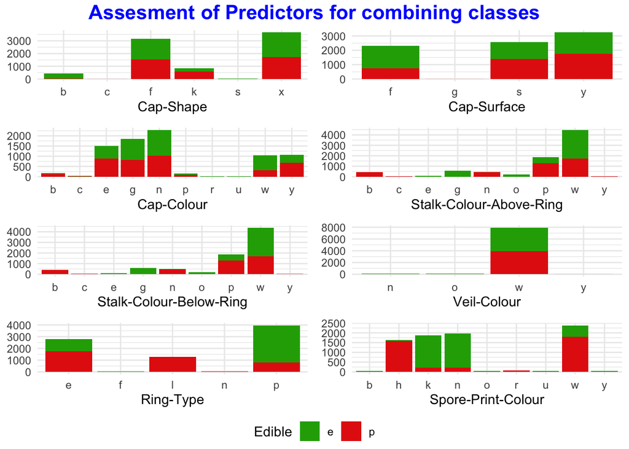

Figure 6: Assessing which predictors to combine lowly populated classes

```r
## create test training split, create test data frame and create training predictors data frame and training response vector
train_index_10 <- createDataPartition(modelData$Edible, p=0.8, list = FALSE, times = 10) # returns numerical vector of the index of the observations to be included in the training set, repeat so we have 10 different test training sets for later
predictors <- names(modelData[-1]) # return vector of column names, removing "Auth" as it is the response variable
```

As outlined above a Naive Bayes Classification model will be used. Caret has many versions of the Naive Bayes model that cna be called. In this case we will use the “nbDiscrete” version. To find the hyperparameter that can be tuned on the model the following code was used.

```r
(modelLookup("nbDiscrete"))
```

```
##        model parameter               label forReg forClass probModel
## 1 nbDiscrete    smooth Smoothing Parameter  FALSE     TRUE      TRUE
```

It shows that only the smoothing (lap-lace smoothing) parameter can be tuned. Lap-Lace smoothing relates to the way the model deals with classes with zero probability as they have not appeared in the training data set. Hopefully the data wrangling in the previous step will eliminate the need for this. For completeness we will check if the model performs differently for smoothing values 1 –> 10.

The training environment was then set up. Training was set to be undertken using 10 fold cross validation over a training grid of one hyper parameter, smoothing, with values from 1:10. This means that the model will be trained on a sub division of 9/10 ths of the training set and assessed on the remaining 1/10 th. The divisions remain unchanged and the model is trained and assesed over each unique combination.

A Discrete Naive Bayes model was then tuned on all 10 test / training data sets with the best hyperparamemter from each set recorded. The best hyperparameter was taken to be the one which produced the highest level of prediction accuracy in the 10 fold cross validation that was undertaken for each training data set. The average of the hyperparameter was then taken from the 10 training sets. This value was then used to train and test a model across each of the 10 training / test sets.

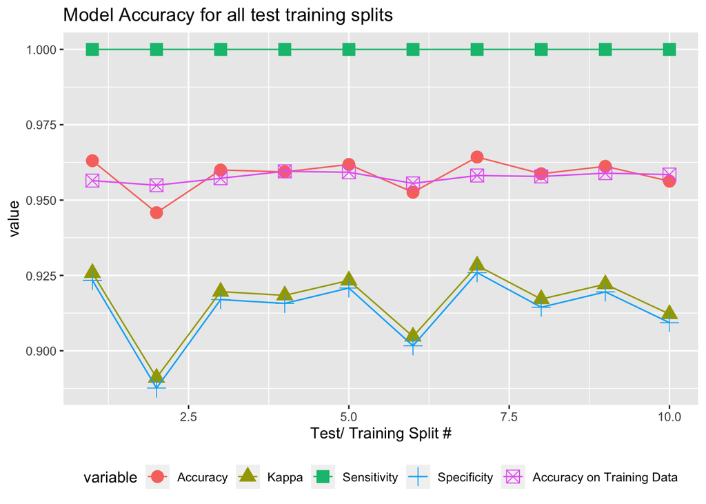

Figure 7: Model Accuracy for each Test/Trainin Split

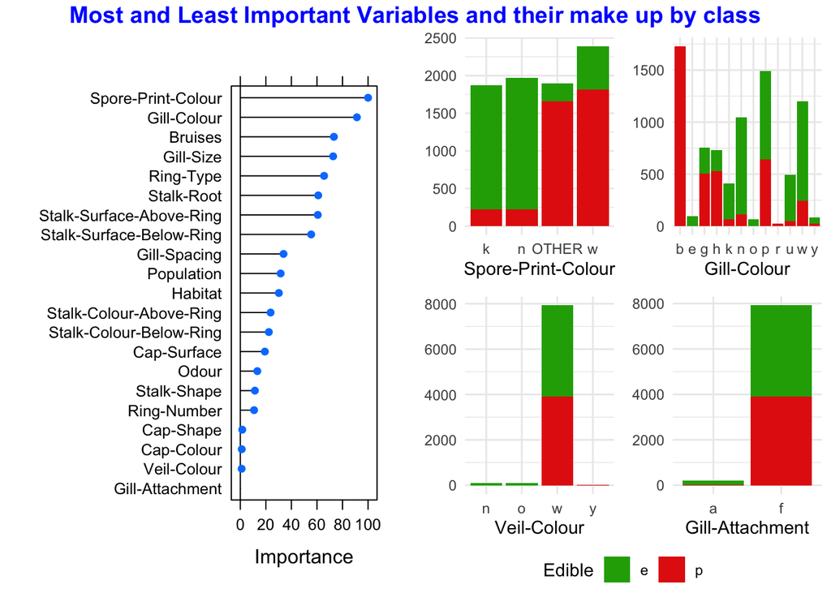

Figure 8: Most and Least Important Variables and their make up by class

Interestingly while the trend for accuracy on the training data is similar the variance is much lower. This shows how the model is affected by some over fitting. When averaged over many test and training sets, as is the case in the training data the predictions are stable. However when this averaging is not available it can be seen that the results become more variable.

This is amplified with the issue we sort to address by combining smaller classes and a few predictors having to large an influence, essentially reducing the models instrumentality to far bellow that of the problems.To further investigate this we will consider the properties of the most and least important predictors in the model. Figure 8 shows the importance of each variable to the model and a breakdown of the most and least important variables.

The qualities which make for a important and un important variable can be clearly seen. In the case of the important variables, if a particular observation is a member of a given class it has a significantly higher likely hood of being either edible or poisons and membership of classes is relatively even. The opposite is true for the least important variables, where membership of a given class is either low or gives no distinctly higher likely hood of being edible or poisons. This differing weighting in the model does reflect the truth, however as the test splits are still only a sample when the variation in the sample differs from the population and / or the training set the model will test as less accurate.

## Question 3

```
## Confusion Matrix and Statistics
##
##             Reference
## Prediction   Authentic Fraudulent
##   Authentic        109          8
##   Fraudulent        13        144
##
##                Accuracy : 0.9234
##                  95% CI : (0.8852, 0.9519)
##     No Information Rate : 0.5547
##     P-Value [Acc > NIR] : <2e-16
##
##                   Kappa : 0.8442
##
##  Mcnemar's Test P-Value : 0.3827
##
##             Sensitivity : 0.8934
##             Specificity : 0.9474
##          Pos Pred Value : 0.9316
##          Neg Pred Value : 0.9172
##              Prevalence : 0.4453
##          Detection Rate : 0.3978
##    Detection Prevalence : 0.4270
##       Balanced Accuracy : 0.9204
##
##        'Positive' Class : Authentic
##
```

```
## Confusion Matrix and Statistics
##
##             Reference
## Prediction   Authentic Fraudulent
##   Authentic        122         11
##   Fraudulent         0        141
##
##                Accuracy : 0.9599
##                  95% CI : (0.9293, 0.9798)
##     No Information Rate : 0.5547
##     P-Value [Acc > NIR] : < 2.2e-16
##
##                   Kappa : 0.9195
##
##  Mcnemar's Test P-Value : 0.002569
##
##             Sensitivity : 1.0000
##             Specificity : 0.9276
##          Pos Pred Value : 0.9173
##          Neg Pred Value : 1.0000
##              Prevalence : 0.4453
##          Detection Rate : 0.4453
##    Detection Prevalence : 0.4854
##       Balanced Accuracy : 0.9638
##
##        'Positive' Class : Authentic
##
```

As discussed in the previous questions, model accuracy can be some what domain specific. In this case as we are looking at fraudulent bank notes, we will assume that we are interested mostly in not classifying any fraudulent cases as authentic. This is a reasonable assumption as classification as fraudulent will simply prompt further investigation which, if a missclassification has occurred can simply be overturned. As we are interested in minimising the number of cases where false negatives are obtained we are striving to maximise the models sensitivity. Figure 9 shows both models accuracy and sensitivity for all 10 test training splits. The LDA model consistently performs exceptionally well. Often this could be at the cost of overall accuracy, however it can also be seen that the LDA models overall accuracy is also higher than the NB model.

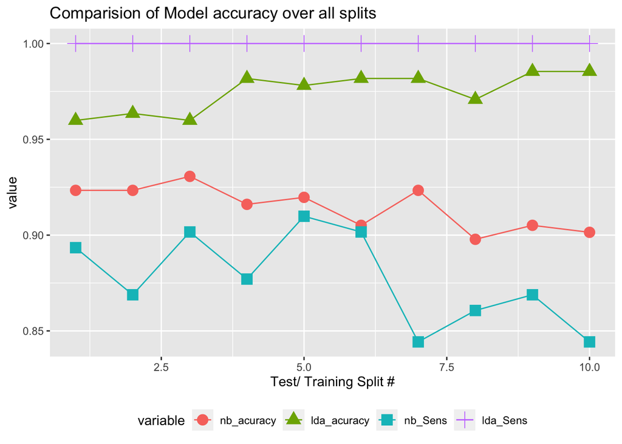

Figure 9: Model Accuracy

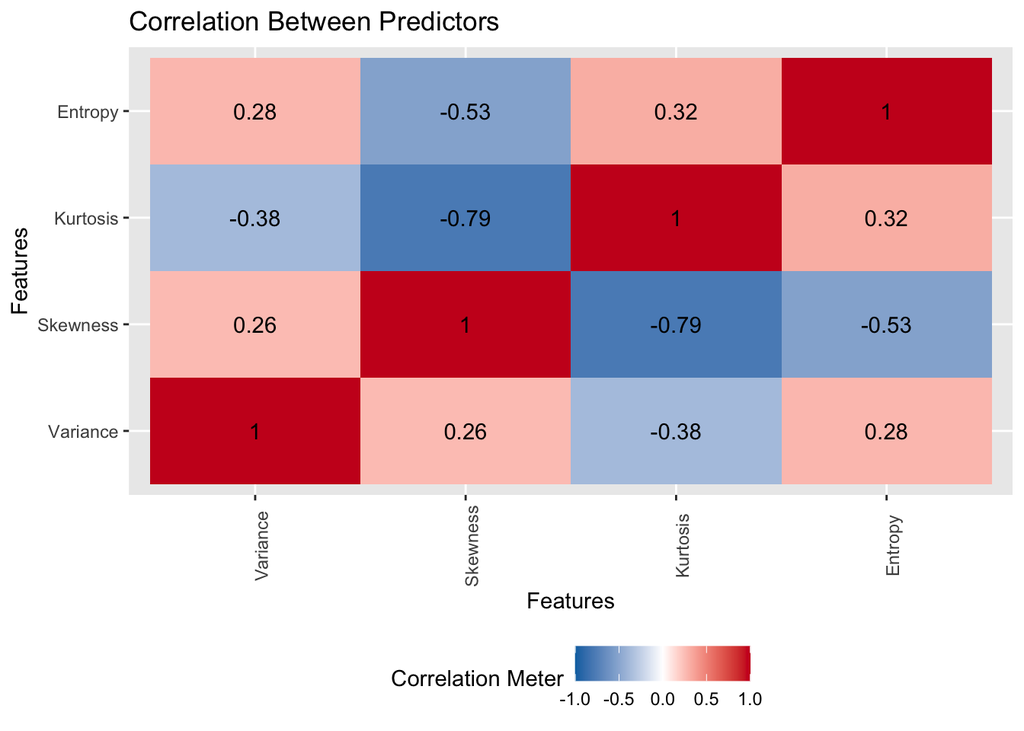

Figure 10: Predictor Correlation Heatmap

The LDA models performance is notably and consistently better than NB. To better understand the drivers for this being the case we will explore the attributes of the underlying data. One of the key differences between the LDA and NB model is that NB assumes that each predictor is independent. The LDA model does not need to assume this property. To investigate if a degree of correlation exists between the predictors a correlation heat map was generated as shown in Figure 10. It can be seen that independence is a poor assumption for this data set as entropy has a reasonably strong negative correlation with skewness and Kurtosis has a strong negative correlation with skewness.

## Appendix 1 - Full R Code

```r
####################
# Start Question 1 #
####################
## set up environment and import data file

rm(list = ls()) # removes all variables
if(!is.null(dev.list())) dev.off() # clear plots
cat("\014") # clear console
setwd("~/Documents/GitHub/ma5810_a1") # set the working directory

# import required packages
library(DataExplorer)
library(ggplot2)
library(ggpubr)

set.seed(123) # sets seed for repeat ability of randomly generated numbers

file <- 'HBblood.csv' # in this case the data is stored as a ".csv" file in the woking directory
rawData <- read.csv(file, header = TRUE, stringsAsFactors = TRUE) # the data is imported, the .csv file has headers which will be used as the column names of the data frame, any stirngs in the data set will be treated as factors

ggplot(rawData) + aes(x = SBP, y = HbA1c, colour = Ethno) + geom_point(shape = "circle", size = 1.5) + scale_color_hue(direction = 1) + theme_minimal() + labs(title = "SBP vs BhA1c")
# create scatter plot with predictor variables on x and y, colour points by Ethno

hb <- ggplot(rawData) + aes(x = HbA1c) + geom_density(adjust = 1L, fill = "#FF8C00") + theme_minimal() # create distribution plot of HbA1c
sb <- ggplot(rawData) + aes(x = SBP) + geom_density(adjust = 1L, fill = "#EF562D") + theme_minimal() # create distribution plot of SBP
densityPlot <- ggarrange(hb,sb, labels = c("HbA1c", "SBP"), ncol = 1, nrow = 2) # group plots together, one on top of the other
annotate_figure(densityPlot, top = text_grob("Density Distributions of Predictor variables HbA1c and SBP", color = "blue", face = "bold", size = 16)) # give the plot frame a common tittle

plot_correlation(rawData[ ,2:3], title = "Correlation Between Predictor Variables") # create a correlation plot to asses correlation and covariance between predictors

hbByGroup <- ggplot(rawData) + aes(x = HbA1c, fill = Ethno) + geom_density(adjust = 1L) + scale_fill_hue(direction = 1) + theme_minimal() # create density plot by groups for HbA1c
sbpByGroup <- ggplot(rawData) + aes(x = SBP, fill = Ethno) + geom_density(adjust = 1L) + scale_fill_hue(direction = 1) + theme_minimal() # create density plot by groups for SBP
groupeddensityPlot <- ggarrange(hbByGroup,sbpByGroup, labels = c("HbA1c", "SBP"), ncol = 1, nrow = 2, common.legend = TRUE, legend = "bottom") # group plots together, one on top of the other
annotate_figure(groupeddensityPlot, top = text_grob("Density Distributions of Predictor variables Grouped by Ethno", color = "blue", face = "bold", size = 16)) # give the plot frame a common tittle

####################
# Start Question 2 #
####################
## set up environment and import csv file

rm(list = ls()) # removes all variables
if(!is.null(dev.list())) dev.off() # clear plots
cat("\014") # clear console
setwd("~/Documents/GitHub/ma5810_a1") # set the working directory

# import required packages
library(caret, warn.conflicts = F, quietly = T)
library(dplyr)
library(bnclassify) # for 'nbDiscrete' model
library(DataExplorer)
library(doParallel)
library(reshape2)
library(ggplot2)

set.seed(123) # sets seed for repeat ability of randomly generated numbers

file <- 'https://archive.ics.uci.edu/ml/machine-learning-databases/mushroom/agaricus-lepiota.data' # store the path to the source data
rawData <- read.csv(file, header = FALSE, stringsAsFactors = TRUE) # import source data, in this case the data file has no headers and strings will be used a factors
names(rawData) <- c("Edible", "Cap-Shape", "Cap-Surface", "Cap-Colour", "Bruises", "Odour", "Gill-Attachment", "Gill-Spacing", "Gill-Size", "Gill-Colour", "Stalk-Shape", "Stalk-Root",  # name data.frame columns
                    "Stalk-Surface-Above-Ring", "Stalk-Surface-Below-Ring", "Stalk-Colour-Above-Ring", "Stalk-Colour-Below-Ring", "Veil-Type", "Veil-Colour", "Ring-Number", "Ring-Type", "Spore-Print-Colour", "Population", "Habitat")

## exploratory visualization of the data set
str(rawData) # returns the structure of the data.frame
introduce(rawData) # returns some basic information about the data
plot_bar(rawData) # generate bar plots showing the count of each variable class

modelData <- within(rawData, rm("Veil-Type")) # drop "veil-Type" as it has only one class
plot_bar(modelData, by = "Edible") # create bar plots of all predictor variables showing the make up of the response variable in each class


ggplot(modelData) + aes(x = `Stalk-Root`, fill = Edible) + geom_bar() + scale_fill_manual(values = c(e = "#23A904", p = "#E42511")) + theme_minimal() + labs(title = "Stalk-Root") # bar plot of Stalk-Root to investigate ?

## create grid of bar plots for predictors that may need to have classes reduced
cs <- ggplot(modelData) + aes(x = `Cap-Shape`, fill = Edible) + geom_bar() + scale_fill_manual(values = c(e = "#23A904", p = "#E42511")) + theme_minimal() + rremove("y.title")
csu <- ggplot(modelData) + aes(x = `Cap-Surface`, fill = Edible) + geom_bar() +scale_fill_manual(values = c(e = "#23A904", p = "#E42511")) + theme_minimal() + rremove("y.title")
cc <- ggplot(modelData) + aes(x = `Cap-Colour`, fill = Edible) + geom_bar() + scale_fill_manual(values = c(e = "#23A904", p = "#E42511")) + theme_minimal() + rremove("y.title")
scar <- ggplot(modelData) + aes(x = `Stalk-Colour-Above-Ring`, fill = Edible) + geom_bar() + scale_fill_manual(values = c(e = "#23A904",  p = "#E42511")) + theme_minimal() + rremove("y.title")
scbr <- ggplot(modelData) + aes(x = `Stalk-Colour-Below-Ring`, fill = Edible) + geom_bar() + scale_fill_manual(values = c(e = "#23A904",  p = "#E42511")) + theme_minimal() + rremove("y.title")
vc <- ggplot(modelData) + aes(x = `Veil-Colour`, fill = Edible) + geom_bar() + scale_fill_manual(values = c(e = "#23A904",  p = "#E42511")) + theme_minimal() + rremove("y.title")
rt <- ggplot(modelData) + aes(x = `Ring-Type`, fill = Edible) + geom_bar() + scale_fill_manual(values = c(e = "#23A904",  p = "#E42511")) + theme_minimal() + rremove("y.title")
sp <- ggplot(modelData) + aes(x = `Spore-Print-Colour`, fill = Edible) + geom_bar() + scale_fill_manual(values = c(e = "#23A904",  p = "#E42511")) + theme_minimal() + rremove("y.title")
```

```r
predictorsToReduce <- ggarrange(cs, csu, cc, scar, scbr, vc,rt, sp, ncol = 2, nrow = 4, common.legend = TRUE, legend = "bottom")  # group plots together, one on top of the other
annotate_figure(predictorsToReduce, top = text_grob("Assesment of Predictors for combining classes", color = "blue", face = "bold", size = 16)) # give the plot frame a common tittle

# group minority classes and change variable type back to factor
modelData <- group_category(data = modelData, feature = "Cap-Colour", threshold = 0.2, update = TRUE)
modelData <- group_category(data = modelData, feature = "Stalk-Colour-Below-Ring", threshold = 0.2, update = TRUE)
modelData <- group_category(data = modelData, feature = "Spore-Print-Colour", threshold = 0.2, update = TRUE)
modelData$`Cap-Colour` <- as.factor(modelData$`Cap-Colour`)
modelData$`Stalk-Colour-Below-Ring` <- as.factor(modelData$`Stalk-Colour-Below-Ring`)
modelData$`Spore-Print-Colour` <- as.factor(modelData$`Spore-Print-Colour`)

rm(rawData, file) # remove variables that will no longer be required

## create test training split, create test data frame and create training predictors data frame and training response vector
train_index_10 <- createDataPartition(modelData$Edible, p=0.8, list = FALSE, times = 10) # returns numerical vector of the index of the observations to be included in the training set, repeat so we have 10 different test training sets for later
predictors <- names(modelData[-1]) # return vector of column names, removing "Auth" as it is the response variable

## check details of choosen model
(modelLookup("nbDiscrete"))

## set up training environment with the details of the validation method and tune grid
train_control <- trainControl(method = "cv", number = 10) # instruct training to occur using k folds cross validation with 10 folds
tune_params_initial <- expand.grid(smooth = 1:10) # create a training grid

## register doParallel
cl <- makePSOCKcluster(4)
registerDoParallel(cl)

start_time <- Sys.time() # record start time of model trainings

## tune model over all 10 test / training splits
all_nb_tune <- lapply(seq_len(ncol(train_index_10)), function(i){ # rather than use "for loop" lapply runs the defined function for all prescribed values of i

  trainingPredictors <- modelData[train_index_10[ ,i],predictors] # create data.frame of training predictors
  trainingResponse <- modelData[train_index_10[ ,i],"Edible"] # create training response vector

  mushroom_mod_tune <- train(x = trainingPredictors, y = trainingResponse, method = "nbDiscrete", trControl = train_control, tuneGrid = tune_params_initial) # train model

  mushroom_mod_tune$finalModel$tuneValue[1,1] # return the hyperparameter for the best model found in the 10 fold cross validation

})

## get final hyper parameters
tune_params_final <- expand.grid(smooth = mean((unlist(all_nb_tune)))) # unlist and average hyperparameter from all 10 training sets

rm(all_nb_tune, tune_params_initial)

## train model across all 10 test / training splits and return accuracy of model each time
all_nb_accuracyTraining <- lapply(seq_len(ncol(train_index_10)), function(i){ # rather than use "for loop" lapply runs the defined function for all prescribed values of i

  trainingPredictors <- modelData[train_index_10[ ,i],predictors] # create data.frame of training predictors
  trainingResponse <- modelData[train_index_10[ ,i],"Edible"] # create training response vector
  mushroom_mod4ass <- train(x = trainingPredictors, y = trainingResponse, method = "nbDiscrete", trControl = train_control, tuneGrid = tune_params_final) # train model

  mushroom_mod4ass$results["Accuracy"] # return the accuracy of the model on the training data

})

trainingAccuracy <- unlist(all_nb_accuracyTraining) # make training accuracy a simple vector showing the average model accuracy on the training data for each test/ train split

## train model across all 10 test / training splits and return confusion matrix each time
all_nb_confusionMatrix <- lapply(seq_len(ncol(train_index_10)), function(i){

  trainingPredictors <- modelData[train_index_10[ ,i],predictors] # create data.frame of training predictors
  trainingResponse <- modelData[train_index_10[ ,i],"Edible"] # create training response vector
  testData <- modelData[-train_index_10[,i], ] # create test data set
  mushroom_mod4ass <- train(x = trainingPredictors, y = trainingResponse, method = "nbDiscrete", trControl = train_control, tuneGrid = tune_params_final) # train model
  pred <- predict(mushroom_mod4ass, newdata = testData) # use model to make predictions using the predictors from the trainingset

  confusionMatrix(pred, testData$Edible) # return confusion matrix for predicted and actual classes

})

end_time <- Sys.time() # record time at end of analysis
runtime <- end_time - start_time # calculate run time


## build data.frame of the performance scores for each test/ training split

nb_acuracy <- lapply(seq_len(length(all_nb_confusionMatrix)), function(i){
  unlist(all_nb_confusionMatrix[[i]]$overall["Accuracy"])
})

nb_Kappa <- lapply(seq_len(length(all_nb_confusionMatrix)), function(i){
  unlist(all_nb_confusionMatrix[[i]]$overall["Kappa"])
})

nb_Sens <- lapply(seq_len(length(all_nb_confusionMatrix)), function(i){
  unlist(all_nb_confusionMatrix[[i]]$byClass["Sensitivity"])
})

nb_Spec <- lapply(seq_len(length(all_nb_confusionMatrix)), function(i){
  unlist(all_nb_confusionMatrix[[i]]$byClass["Specificity"])
})

performance <- data.frame(c(1:10), unlist(nb_acuracy), unlist(nb_Kappa), unlist(nb_Sens), unlist(nb_Spec), trainingAccuracy)
names(performance) <- c("Test/ Training Split #", "Accuracy","Kappa", "Sensitivity","Specificity", "Accuracy on Training Data")

rm(nb_acuracy, nb_Kappa, nb_Sens, nb_Spec, all_nb_confusionMatrix)

## train model on single test training set to inspect the importance of individual variables and easily look into model results

trainingPredictors <- modelData[train_index_10[ ,1],predictors] # create data.frame of training predictors
trainingResponse <- modelData[train_index_10[ ,1],"Edible"] # create training response vector
testData <- modelData[-train_index_10[,1], ] # create test data set
mushroom_mod4ass <- train(x = trainingPredictors, y = trainingResponse, method = "nbDiscrete", trControl = train_control, tuneGrid = tune_params_final) # train model
pred <- predict(mushroom_mod4ass, newdata = testData) # use model to make predictions using the predictors from the trainingset
confusionMatrix(pred, testData$Edible) # return confusion matrix for predicted and actual classes
```

```r
performance_flat <- melt(performance, id.vars = 1) # flatten performance for easy use in ggplot
ggplot(data = performance_flat, aes(x =`Test/ Training Split #`, y = `value`, shape = `variable`, colour = `variable`)) + geom_point(size = 4) + geom_line() + theme(legend.position = "bottom") + ggtitle("Model Accuracy for all test training splits") # plot each performance metric for each test / train split, with lines between points to easily identify trends

## plot plot variable importance
varimp <- varImp(mushroom_mod4ass)
var <- plot(varimp)
## plot the 2 most and least important variable for discussion
spc <- ggplot(modelData) + aes(x = `Spore-Print-Colour`, fill = Edible) + geom_bar() + scale_fill_manual(values = c(e = "#23A904", p = "#E42511")) + theme_minimal() + rremove("y.title")
gc <- ggplot(modelData) + aes(x = `Gill-Colour`, fill = Edible) + geom_bar() +scale_fill_manual(values = c(e = "#23A904", p = "#E42511")) + theme_minimal() + rremove("y.title")
vc <- ggplot(modelData) + aes(x = `Veil-Colour`, fill = Edible) + geom_bar() + scale_fill_manual(values = c(e = "#23A904", p = "#E42511")) + theme_minimal() + rremove("y.title")
ga <- ggplot(modelData) + aes(x = `Gill-Attachment`, fill = Edible) + geom_bar() + scale_fill_manual(values = c(e = "#23A904",  p = "#E42511")) + theme_minimal() + rremove("y.title")
comparision <- ggarrange(spc, gc, vc, ga, ncol = 2, nrow = 2, common.legend = TRUE, legend = "bottom")  # group plots together, one on top of the other
all <- ggarrange(var, comparision, ncol = 2, nrow = 1)
annotate_figure(all, top = text_grob("Most and Least Important Variables and their make up by class", color = "blue", face = "bold", size = 14)) # give the plot frame a common tittle

####################
# Start Question 3 #
####################
## set up environment and import data file

rm(list = ls()) # removes all variables
if(!is.null(dev.list())) dev.off() # clear plots
cat("\014") # clear console
setwd("~/Documents/GitHub/ma5810_a1") # set the working directory

# import required packages
library(caret, warn.conflicts = F, quietly = T)
library(dplyr)
library(DataExplorer)
library(doParallel)
library(esquisse)
library(reshape2)

set.seed(123) # sets seed for repeat ability of randomly generated numbers

file <- 'https://archive.ics.uci.edu/ml/machine-learning-databases/00267/data_banknote_authentication.txt' # store the path to the source data
rawData <- read.csv(file, header = FALSE) # import source data, in this case the data file has no headers and strings will be used a factors
names(rawData) <- c("Variance", "Skewness","Kurtosis", "Entropy", "Auth") # set column names in data.frame
rawData <- rawData %>% mutate(Auth = ifelse(Auth == 1, "Authentic", "Fraudulent")) # change the values Auth with an observation of 1 to "True", otherwise "False"
rawData$Auth <- as.factor(rawData$Auth) # make the "Auth" column a factor

## exploratory visualization of the dataset and summation of data set
str(rawData)
introduce(rawData)
head(rawData)
summary(rawData)
plot_histogram(rawData)
plot_bar(rawData)
plot_qq(rawData)
plot_correlation(rawData[ ,1:4])

modelData <- rawData # the raw data set looks suitable to model with

## create test training split, create test data frame and create training predictors data frame and training response vector
train_index_10 <- createDataPartition(modelData$Auth, p=0.8, list = FALSE, times = 10) # returns numerical vector of the index of the observations to be included in the training set, repeat so we have 10 different test training sets for later
train_index <- train_index_10[ ,1] # tuining hyperparaemters over a single test set is suitable so split out first index
predictors <- names(modelData[-5]) # return vector of column names, removing "Auth" as it is the response variable

testData <- modelData[-train_index, ] # create data.frame of test data
trainingPredictors <- modelData[train_index,predictors] # create data.frame of training predictors
trainingResponse <- as.factor(modelData[train_index, "Auth"]) # create vector of training responses

rm(rawData, file) # remove unused variables

## register doParallel
cl <- makePSOCKcluster(4)
registerDoParallel(cl)

## train and tune Naive Bayes classifier using caret. We will first tune both models using a single test and training data set to obtain the best hyperparameters for each model
start_time <- Sys.time() # record start time

train_control <- trainControl(method = "cv", number = 10) # use 10 fold cross validation on the training set to asses model hyper parameters
tune_params <- expand.grid(usekernel = c(TRUE, FALSE), fL = 1:5, adjust = 1:5) # create tuning grid over available hyper parameters for NB model

bank_nb<- train(x = trainingPredictors, y = trainingResponse, method = "nb", trControl = train_control, tuneGrid = tune_params, metric = "Accuracy") # train model
bank_nb_final <- bank_nb$finalModel # save the most acurate model

tune_params <- expand.grid(dimen = 0:10) # create tuning grid over available hyper parameters for LDA model

bank_lda <- train(x = trainingPredictors, y = trainingResponse, method = "lda2", trControl = train_control, tuneGrid = tune_params, metric = "Accuracy") # train model
bank_lda_final <- bank_lda$finalModel # save most accurate model

rm(tune_params, train_index, trainingPredictors, trainingResponse)

## create confusion matrix to summarize each model
pred <- predict(bank_nb, newdata = testData) # use model to make predictions using the predictors from the trainingset
confusionMatrix(pred, testData$Auth) # return confusion matrix for predicted and actual classes
pred <- predict(bank_lda, newdata = testData) # use model to make predictions using the predictors from the trainingset
confusionMatrix(pred, testData$Auth) # return confusion matrix for predicted and actual classes

rm(pred) # remove unused variables

## compare models over 10 different test/training data sets
tune_params_nb <- expand.grid(usekernel = bank_nb_final$tuneValue[1,2], fL = bank_nb_final$tuneValue[1,1], adjust = bank_nb_final$tuneValue[1,3]) # set the model hyper parameters to the values that were best from the above step
tune_params_lda <- expand.grid(dimen = bank_lda_final$tuneValue[1,1]) # set the model hyper parameters to the values that were best from the above step
```

```r
all_nb <- lapply(seq_len(ncol(train_index_10)), function(i){ # rather than use "for loop" lapply runs the defined function for all prescribed values of i

  trainingPredictors <- modelData[train_index_10[ ,i],predictors] # create data.frame of training predictors
  trainingResponse <- modelData[train_index_10[ ,i],"Auth"] # create training response vector
  testData <- modelData[-train_index_10[,i], ] # create data.frame of tests data
  bank_mod4ass_nb <- train(x = trainingPredictors, y = trainingResponse, method = "nb", trControl = train_control, tuneGrid = tune_params_nb) # train model
  pred <- predict(bank_mod4ass_nb, newdata = testData) # use model to create predictions

  confusionMatrix(pred, testData$Auth) # return confusion matrix

})

all_lda <- lapply(seq_len(ncol(train_index_10)), function(i){ # rather than use "for loop" lapply runs the defined function for all prescribed values of i

  trainingPredictors <- modelData[train_index_10[ ,i],predictors] # create data.frame of training predictors
  trainingResponse <- modelData[train_index_10[ ,i],"Auth"] # create training response vector
  testData <- modelData[-train_index_10[,i], ] # create data.frame of tests data
  bank_mod4ass_lda <- train(x = trainingPredictors, y = trainingResponse, method = "lda2", trControl = train_control, tuneGrid = tune_params_lda) # train model
  pred <- predict(bank_mod4ass_lda, newdata = testData) # use model to create predictions

  confusionMatrix(pred, testData$Auth) # return confusion matrix

})

end_time <- Sys.time() # record end tiem of models
(runtime <- end_time - start_time) # calculate run time


## close cluster
stopCluster(cl)

## unpacked the performance metrics from the LDA and NB confusion matrices

lda_acuracy <- lapply(seq_len(length(all_lda)), function(i){
  unlist(all_lda[[i]]$overall["Accuracy"])
})

lda_Kappa <- lapply(seq_len(length(all_lda)), function(i){
  unlist(all_lda[[i]]$overall["Kappa"])
})

lda_Sens <- lapply(seq_len(length(all_lda)), function(i){
  unlist(all_lda[[i]]$byClass["Sensitivity"])
})

lda_Spec <- lapply(seq_len(length(all_lda)), function(i){
  unlist(all_lda[[i]]$byClass["Specificity"])
})

nb_acuracy <- lapply(seq_len(length(all_nb)), function(i){
  unlist(all_nb[[i]]$overall["Accuracy"])
})

nb_Kappa <- lapply(seq_len(length(all_nb)), function(i){
  unlist(all_nb[[i]]$overall["Kappa"])
})

nb_Sens <- lapply(seq_len(length(all_nb)), function(i){
  unlist(all_nb[[i]]$byClass["Sensitivity"])
})

nb_Spec <- lapply(seq_len(length(all_nb)), function(i){
  unlist(all_nb[[i]]$byClass["Specificity"])
})

performance<- data.frame(c(1:10), unlist(nb_acuracy), unlist(lda_acuracy), unlist(nb_Kappa), unlist(lda_Kappa), unlist(nb_Sens), unlist(lda_Sens), unlist(nb_Spec), unlist(lda_Spec)) # create data frame of performance metrics

names(performance) <- c("Test/ Training Split #", "nb_acuracy","lda_acuracy", "nb_Kappa", "lda_Kappa", "nb_Sens", "lda_Sens", "nb_Spec", "lda_Spec") # name columns of data frame

rm(lda_acuracy , lda_Kappa, lda_Sens, lda_Spec, nb_acuracy, nb_Kappa, nb_Sens, nb_Spec) # remove unused variables

## Plot comparison of model performance
performance_reduced <-performance[ , c(1,2,3,6,7)]
performance_flat <- melt(performance_reduced, id.vars = 1) # flatten performance for easy use in ggplot
ggplot(data = performance_flat, aes(x =`Test/ Training Split #`, y = `value`, shape = `variable`, colour = `variable`)) + geom_point(size = 4) + geom_line() + theme(legend.position = "bottom") + ggtitle("Comparision of Model accuracy over all splits") # plot each performance metric for each test / train split, with lines between points to easily identify trends

## Plot correlation for discusions regarding assumptions
plot_correlation(modelData[ ,1:4], title = "Correlation Between Predictors") # create correlation heat map
```